# The R in Robotics

The aim of this contribution is to connect two previously separated worlds: robotic application development with the Robot Operating System (ROS) and statistical programming with R. This fruitful combination becomes apparent especially in the analysis and visualization of sensory data. We therefore introduce a new language extension for ROS that allows to implement nodes in pure R. All relevant aspects are described in a step-by-step development of a common sensor data transformation node. This includes the reception of raw sensory data via the ROS network, message interpretation, bag-file analysis, transformation and visualization, as well as the transmission of newly generated messages back into the ROS network.

André Dietrich, Sebastian Zug, and Kaiser (Department of Distributed Systems, Otto-von-Guericke-Universität Magdeburg)  
2013-12-13

## 1 Introduction

The development of robotic applications has become more and more an interdisciplinary task, ranging from mechanical and electrical engineering, signal processing, control technology and cybernetics, up to artificial intelligence, etc. The Robot Operating System[^1], abbreviated as ROS, is a relatively new framework, intended to simplify the development of any kind of robotic application by bringing together the latest scientific knowledge. And by the time it has become a de facto standard in the scientific robotics community (cf. Kramer and Scheutz 2007). In order to disseminate a certain algorithm, toolbox, or function, a large number of developers provide interfaces to ROS. Currently there are more than 1700 different packages available online for various purposes, for example “Marker Detection”, “Simultaneous Localization And Mapping”, “Trajectory Planning”, and many more. These packages can easily be used, combined, and integrated into new applications, with only a little knowledge about the ROS philosophy. Robotic applications are no longer designed as single and monolithic processes, but instead as a collection of nodes, which perform a certain type of computation, similar to the UNIX philosophy (cf. Salus 1994): “*Write programs that do one thing and do it well. Write programs to work together. Write programs to …*”. The development of a ROS node is mainly based on two philosophical pillars (apart from open source ideology), namely multilingualism and peer-to-peer (cf. Quigley et al. 2009).

Multilingualism means to implement a node in the most appropriate programming language. In most cases C++ (roscpp[^2]) is the ideal choice for developing a node (cf. Quigley et al. 2013), especially to fulfill hardware-related or computationally expensive functionalities, whereas Python (rospy) is suitable for rapid prototyping, scripting, and GUI development. The Lisp language support (roslisp) was also intended for scripting, but is mostly employed for fast and interactive debugging. Next to these programming languages with full ROS support, there are also other “experimental” language[^3]-extensions, serving different needs. Java ([rosjava](http://docs.rosjava.googlecode.com/hg/rosjava_core/html/index.html)) allows developers to build nodes for Android, while Lua (roslua) currently is used for scripting reactive robot behavior.

The interconnection between nodes is established at run time in a peer-to-peer topology, using publish/ subscribe or service-based communication. This allows to run nodes on different hosts and it enables their dynamic integration and segregation. For this purpose, ROS guarantees mutual understanding (and thus interoperability) by explicit message descriptions.

Until now, it was not possible to develop nodes in the statistical programming language R. R is probably not the best choice for implementing fancy GUIs or to develop hardware drivers, but it has by far one of the richest libraries for statistical analyses, data-mining, machine learning, and visualization. According to the comparison of statistical packages on (Wikipedia 2013), R is the only product that has support for every listed demand (unlike MATLAB or SciPy). Furthermore, most of its algorithms are directly implemented in C or C++, which guarantees fast and efficient computation.

In light of these qualities, R is an adequate programming language for sensor signal analysis, evaluation and visualization. These types of tasks are very important for embedded or robotic applications where developers cope with non-linear behavior, different measurement faults or external disturbances. An exemplary evaluation of sensor data is described in (Dietrich et al. 2010). The presented infrared sensors can be easily disturbed by external light, leading to faulty measurements. But these external disturbances also affect the measurement noise in such a way that it can be detected by applying statistical tests – an ideal application for R.

#### Overview

This work is intended to serve two tasks. On the one hand, we want to introduce ROS and present its general development principles to the common R developer. On the other hand, we want to convince ROS developers to use R for certain types of computation. To demonstrate the utility of combining ROS and R, we chose a quite common application, the linearization of sensor distance measurements. In a tutorial-like section we will highlight all relevant aspects in a step-by-step development of an R node. This node will receive raw sensor data, perform a linearization, visualize and publish the resulting values.

Before we describe how to develop a ROS node in pure R and how to install our [*rosR*](http://www.ros.org/wiki/rosR) package, we will give a brief introduction to the common ROS communication principles in the next section. Some limitations of R made it difficult to implement *rosR* as a typical R library, such as single threading, problems in supporting sockets and in handling raw data streams. Instead we developed a common ROS package, which furthermore required to interface several ROS packages. To ease the interconnection of ROS C++ functionality with R we applied the Simplified Wrapper and Interface Generator (SWIG-2.0 2013). The second-last section deals with these implementation details as well as the project structuring and should afterwards allow to extend the package with custom functionality. We conclude our paper with a summary.

## 2 ROS communication principles

As already mentioned, ROS offers two basic communication principles, publish/subscribe and service-based communication. The participation of an R node within a ROS network requires the implementation of these paradigms. Hence, we briefly introduce both concepts, although *rosR* currently does not support services.

### 2.1 Publish/Subscribe

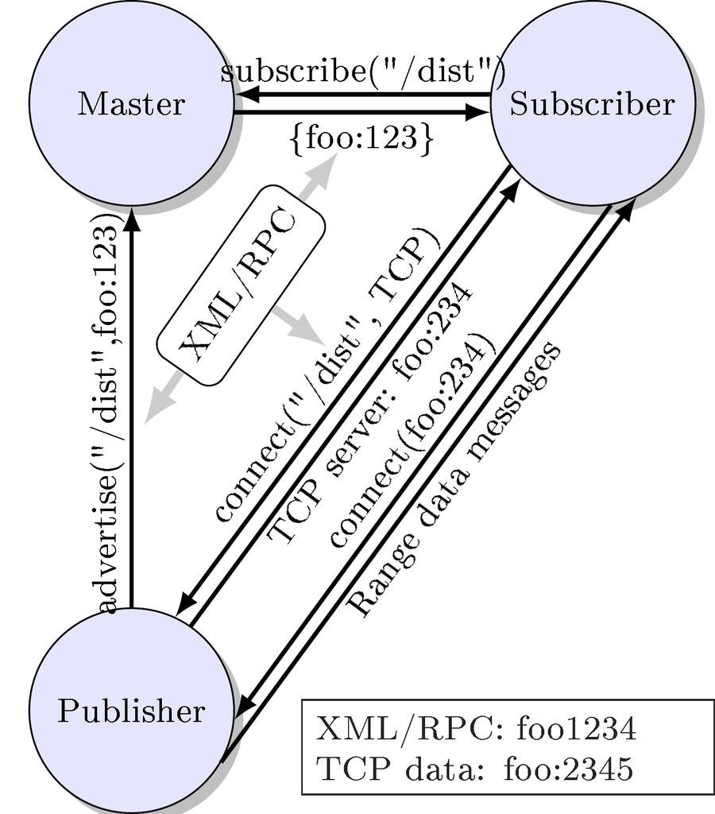

Figure 1: Communication initialization between a publishing and a subscribing node.

The main idea behind publish/subscribe (pub/sub) is to decouple the production and consumption of data. In contrast to the widely used address-based communication paradigm, it offers content-based communication. But, as in most cases including ROS pub/sub, this is just an overlay on address-based communication. Topics in this sense define logical channels that transport all related messages. In ROS, a channel is tagged by a unique string, such as `/map`, `/odometry`, or `/laserscan`, which identifies the content of a channel and its message format. Messages are strongly typed data structures, composed of different primitive types (e. g., `string`, `integer`, `float`, `array`, etc.), similar to structs in C. ROS provides a number of standard data types for certain sensors or tasks. But a user can define individual or adapted message formats related to specific purposes. A publisher (producing node) advertises its intent to publish on a topic, while a subscriber (consuming node) indicates its interest on one or more topics. In ROS there is a central master node that provides name registration and lookup for all connected nodes. The steps for establishing a connection been both parties are depicted in Figure 1. Thus, data is only transmitted, if there is at least one publisher and one subscriber for one topic.

### 2.2 Services

Pub/sub is ideal for dynamic and flexible message passing, but in some cases it might be more useful to request for a certain type of data (e. g., camera parameters, robot states, etc.) or the execution of an action (e. g., grasping an object, planning a trajectory, etc.). This kind of remote procedure call is handled via services. Nodes offer their services by using string names, similar to topics in pub/sub, and clients can call these services by sending their request in an appropriate message format, awaiting the reply message. The connection between both entities is also instantiated with the help of the master, as seen in Figure 1.

### 2.3 Parameters

The access to the parameter server is often mentioned as a third communication method, comparable to shared memory. Parameters are stored at runtime in a multivariate dictionary, which is also hosted by the ROS master node. It is mainly applied for simple configuration purposes, but it also allows to inspect and to modify the global configuration.

## 3 Installation

First of all ROS has to be installed and configured. Good installation guides can be found on http://www.ros.org/wiki/ROS/Installation. Additionally, we put an extensive installation description for Ubuntu 12.04 and ROS “Groovy Galapagos” on our project site http://www.ros.org/wiki/rosR#R-Side. The install manual was intended to guide R developers with no or only a little ROS experience. Information on further developments and adaptations for new ROS versions will be available on the project website too. Before compiling our *rosR* package, there are three things required (apart from an ROS-base and a R-base):

1. SWIG is responsible for interfacing the C++ code (only SWIG2.0 is able to generate appropriate wrappers for R),
2. the R development packages for C++ [*Rcpp*](https://CRAN.R-project.org/package=Rcpp) (cf. Eddelbuettel and François 2011),
3. and a running subversion client to be able to download our package via:`$ svn co http://svn.code.sf.net/p/ivs-ros-pkg/code/trunk/rosR`

Finally, simply enter the installation folder of *rosR* and run the shell-command `rosmake` (cf. Foote 2013). If everything compiled successfully, you should be able to launch a simple test application with:

```r
$ roslaunch rosR random.launch
```

## 4 How-to develop a *rosR* node

As already mentioned, this section is intended to demonstrate how to use the *rosR* API, by developing a node responsible for a common sensor data transformation. For this purpose we chose a common infrared distance sensor, the Sharp GP2D120 (cf. Cooperation 2007). We start with a very basic application and extend it in the following subsections. The complete source code for every example as well as the attached sensor measurements can be downloaded from the following ROS project repository (which can be treated as any ordinary ROS package and therefore has to be built with rosmake:

```r
$ svn co http://svn.code.sf.net/p/ivs-ros-pkg/code/trunk/rosR_demos
```

Every subsection will tackle an individual development part and in doing so, will also explain some internal ROS matters, which makes it necessary to switch between the R-terminal and the command-line shell. `$` is used to indicate the shell usage `>` and `+` indicate R-commands, while `#` is used for comments in both cases.

With the following shell-command you start the replay of previously recorded ROS data, gathered from a Sharp infrared distance sensor. It will also start a ROS master. Therefore, the user should not cancel it, because then it will not be possible to subscribe to any kind of data or to publish any sensor data.

```r
$ # replay of data (using rosbag) from rosR_demos/nodes/RJournal/sharpGP2D120.bag
$ roslaunch rosR_demos sharp-playbag.launch
```

### 4.1 Node initialization

Because we have developed a typical ROS package, which can be located anywhere on your system, it has to be loaded manually. Run the following command in R to load all required functionality. It invokes the system call `rospack find` (cf. Gerkey et al. 2013), which is responsible for locating the current *rosR* installation directory.

```r
> source(paste(system("rospack find rosR", intern = TRUE), "/lib/ros.R", sep = ""),
+   chdir = TRUE)
```

Each command of our API starts with `ros.`, so that the auto-completion, after entering `ros.` into the R-terminal, should present the same result. These are all functions that are required to participate in every ROS network and to publish and subscribe for messages.

```r
> ros.
ros.BagRead     ros.Logging          ros.ParamType                    ros.TimeNow
ros.Debug       ros.Message          ros.Publisher                    ros.Warn
ros.Error       ros.OK               ros.ReadMessage                  ros.WriteMessage
ros.Fatal       ros.ParamDelete      ros.SpinOnce
ros.Info        ros.ParamGet         ros.Subscriber
ros.Init        ros.ParamSet         ros.SubscriberHasNewMessage
```

First of all, and as it is required for all ROS nodes, the node has to be registered as a new participant by announcing at the ROS master with an arbitrary but unique identifier. This can be done with the R-command:

```r
> ros.Init("R_demo")
```

ROS also provides a monitoring tool `rxgraph` (cf. Conley 2013b) that shows all active applications (“nodes”) and active connections between them. Starting this tool from the shell should show the same result, as presented in Figure 2 below. By examining these nodes, you will see that our newly created node is neither subscribed to nor publishing on a certain topic, while `rosbag` (cf. Field et al. 2013) is continuously publishing `Float32` data under topic `/sharpGP2D120/Voltage`.

1. before subscribing
2. after subscribing

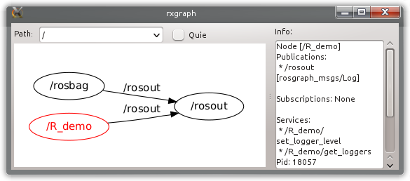

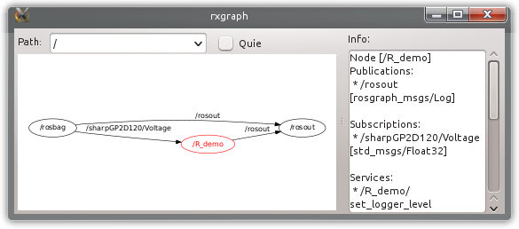

Figure 2: Connectivity graphs, created with the shell-command `rxgraph`, both show additional information about node `“R_demo”` on the right.

### 4.2 Subscriptions and logging

Within this section, we will show how to subscribe to and receive messages from other ROS nodes. A subscription in R can be created as easily as in other programming languages. The only relevant parameters are the topic and the message type (we will handle messages in more detail within subsection “4.6”). The function call as listed below creates a new subscription and also changes the connectivity graph of the ROS network, as depicted in Figure 2.

```r
> subscription <- ros.Subscriber("/sharpGP2D120/Voltage", "std_msgs/Float32")
```

Due to the fact that R is single-threaded and the lack of native support for callbacks, we have to continuously poll for new messages. The code snippet below faciliates this:

```r
> while(ros.OK()) {  # evaluates to TRUE as long as the master is online
+     ros.SpinOnce() # fill the subscription buffers with new messages
+     if(ros.SubscriberHasNewMessage(subscription)) {
+         message <- ros.ReadMessage(subscription)
+         ros.Info( paste("Measured Voltage", message$data) )
+ } }
[ INFO] [1374149363.939419670]: Measured Voltage 0.675665080547333
[ INFO] [1374149364.069367143]: Measured Voltage 0.713892936706543
...
```

Function `ros.SpinOnce()` is responsible for filling the message buffers of all generated subscribers with the newest message at once. The fact that a subscriber has received a new message or not, is indicated with the function call `ros.SubscriberHasNewMessage()`. This has to be called for every subscription. The last message that was received can be read out with function `ros.ReadMessage()`. A message remains in the message buffer of a subscriber as long as it is not overwritten by a newly received message (`ros.SpinOnce()`).

Instead of using the standard `print` function of R to print out the content of the message, it is also possible to use some of ROS’s logging functionalities `ros.Logging(text, mode)` or the abbreviations for different modes. These are `ros.Debug(text)`, `ros.Info(text)`, `ros.Warn(text)`, `ros.Error(text)`, and `ros.Fatal(text)`. The usage of these functions enable a user to debug an application, consisting of multiple nodes, since this information is published to node `rosout` and can be further analyzed with various tools, compare with Figure 3.

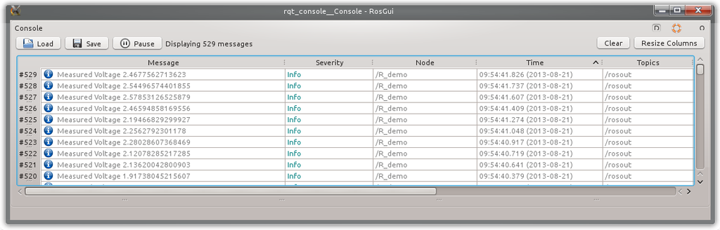

Figure 3: Screenshot of `rqt_console` (cf. Blasdel 2013), a viewer that displays logs of various nodes.

### 4.3 Executable scripts

Two things are required, to start the example from above as a R-script from the shell. A comment at the first line of the script, which defines the correct interpreter:

```r
#!/usr/bin/r
```

The script also has to be made executable, which can be done with the shell-command `chmod`:

```r
$ chmod +x script.R
```

Afterwards it is possible to run the script in the same way as any other ordinary ROS node. The script that we had developed so far can be found at [`rosR_demos/nodes/RJournal/demo0.R`](http://svn.code.sf.net/p/ivs-ros-pkg/code/trunk/rosR_demos/nodes/RJournal/demo0.R) (this folder also contains further examples) and is started from the shell with `rosrun` (cf. Leibs and Kruse 2013):

```r
$ rosrun rosR_demos demo0.R
```

### 4.4 Time and visualization

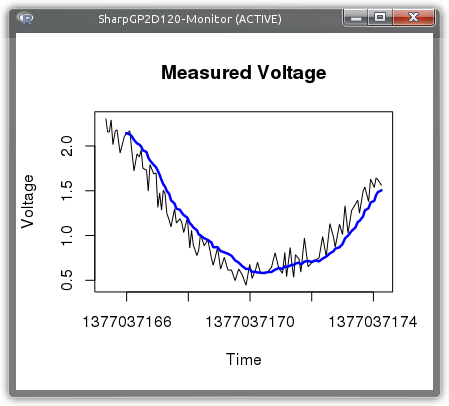

Figure 4: `$ rosrun rosR_demos demo1.R`

Since we started out by stating how easy it is to visualize data with R, the snippet below shows an improved version of the previous code. The voltage values and their reception time are stored within two vectors, which are updated and plotted during every processing cycle. Furthermore, a filter is applied to smooth the results of the measurements. The resulting visualization is shown in Figure 4 and the corresponding source code can be examined at [`rosR_demos/nodes/RJournal/demo1.R`](http://svn.code.sf.net/p/ivs-ros-pkg/code/trunk/rosR_demos/nodes/RJournal/demo1.R).

```r
> x11(width = 6, height = 4,
+     title = "SharpGP2D120-Monitor")
> Voltage <- Time <- rep(NA, 100)
> while(ros.OK()) {
+   ros.SpinOnce()
+   if (ros.SubscriberHasNewMessage(subscription)){
+     message <- ros.ReadMessage(subscription)
+     Voltage <- c(Voltage[-1], message$data)
+     Time <- c(Time[-1], ros.TimeNow())
+     plot(Time, Voltage, t = "l",
+          main = "Measured Voltage")
+     lines(Time,
+       filter(Voltage, rep(0.1, 10), sides = 1),
+              type = "l", col = "blue", lwd = 2.5)
+ }}
```

The only newly used ROS function is `ros.TimeNow()`. It returns the global system time of the ROS master as `double` value, as presented below. The dot separates between seconds since the first of January 1970 and nanoseconds (everything after the decimal point).

```r
> as.POSIXlt(ros.TimeNow(), origin="1970-01-01")       > ros.TimeNow()
[1] "2013-07-18 15:46:26 CEST"                         [1] 1374155184.932926893234
```

### 4.5 Bag-files and linearization

The conversion of non-linear voltage outputs into usable distance measurements is a frequently occurring tasks, by dealing with raw sensor data. The data sheet from the (Cooperation 2007) provides a voltage-distance characteristic, which is quite similar to our measurements depicted in Figure 5. These measurements (sensor output voltage and manually controlled distance) were stored additionally in the bag-file that is currently replayed by rosbag to publish the voltage values of Sharp distance sensor. A bag is a standard format in ROS for storing any kind of ROS messages. Reading in messages from a bag-file, to analyze their content in R, is therefore also provided by our API. Next to replaying messages, rosbag can also be used for recording messages and inspecting bag-files, as it is presented below:

```r
$ rosbag info rosR_demos/nodes/RJournal/sharpGP2D120.bag
...
start:       Nov 19 2013 14:03:28.91 (1384866208.91)
end:         Nov 19 2013 14:28:42.09 (1384867722.09)
size:        39.6 KB
messages:    554
compression: none [1/1 chunks]
types:       rosR_demos/Linearization [3f7dd391cdbb9d1f72822c152e8c430f]
             std_msgs/Float32         [73fcbf46b49191e672908e50842a83d4]
topics:      /sharpGP2D120/Linearization   240 msgs    : rosR_demos/Linearization
             /sharpGP2D120/Voltage         314 msgs    : std_msgs/Float32
```

The result shows that there are two different topics in two different message formats. The voltage values to which we had subscribed `/sharpGP2D120/Voltage` and `/sharpGP2D120/Linearization`, which contains the previously measured distance/voltage values. This message format is defined in [`rosR_demos/msg/Linearization.msg`](http://svn.code.sf.net/p/ivs-ros-pkg/code/trunk/rosR_demos/msg/Linearization.msg) and is composed of two `Float32` values. Reading these messages from the bag-file into R can be done with the function `ros.BagRead`. The required input parameters are the filename and a vector of strings that defines the topics of interest:

```r
> file <- paste(system("rospack find rosR_demos", intern = TRUE),
+               "/nodes/RJournal/sharpGP2D120.bag", sep = "")
> bag.data <-  ros.BagRead(file, c("rosR_demos/Linearization"))
```

The result is a list consisting of four vectors, these are the topic names, message types, timestamps, and the messages themselves (the details of message conversion are explained in the next subsection):

```r
> bag.data$topic[2]                           > bag.data$message[2]
[1] "/sharpGP2D120/Linearization"             [[1]]
> bag.data$data_type[2]                       [[1]]$dist
[1] "rosR_demos/Linearization"                [1] 0.031
> bag.data$time_stamp[2]                      [[1]]$volt
[1] 1374499648.961932659149                   [1] 3.0251
```

Before fitting a suitable equation to describe the relation between distance and voltage, we have to transform the linearization messages into an appropriate R format (`data.frame`). In the code example below, this happens by extracting all required values with the help of `sapply`:

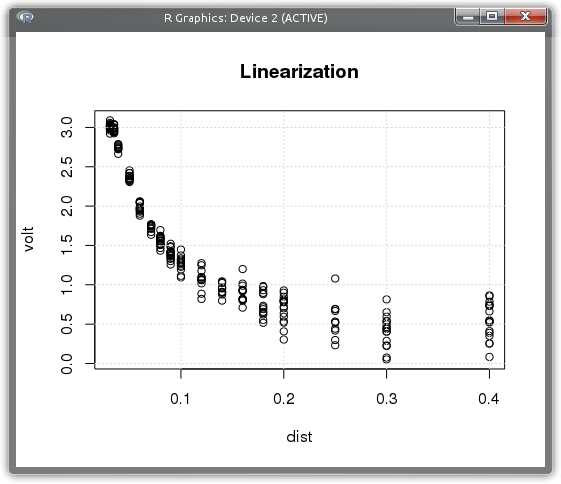

Figure 5: `> plot(sharp.data,main=’Lin...’)`

```r
> # Copy data
> dist <- sapply(bag.data$message,
+                "[[", "dist")
> volt <- sapply(bag.data$message,
+                "[[", "volt")
> sharp.data <- data.frame(dist, volt)
> plot(sharp.data, main = "Linearization")
>
> # Linearization
> sharp.reg <- lm(dist ~ poly(volt, 8),
+                 data = sharp.data)
> sharp.dist <- function(volt) {
+  predict(sharp.reg,data.frame(volt))
+ }
>
> # Test 1            > # Test 2
> sharp.dist(0.8)     > sharp.dist(2.0)
[1] 0.1638513         [1] 0.0613970
```

We decide to approximate the relation by a polynom. Previous investigations showed, that a polynom with a degree of 8 meets our expectations related to the maximum deviation. This is pretty straight forward in R and can be realized with `lm` within one line. The following line defines a function that makes predictions based on the fitted polynom. The predictions made by the resulting linearization function `sharp.dist` are quite close to the measurements in data sheet (Cooperation 2007). The confidence intervals of this linearization are depicted in Figure 6. See also [`rosR_demos/nodes/RJournal/demo2.R`](http://svn.code.sf.net/p/ivs-ros-pkg/code/trunk/rosR_demos/nodes/RJournal/demo2.R), which contains the source code of the running example.

### 4.6 Publishing new messages

This subsection concludes our attempts at developing ROS nodes in R. While the first part describes message handling and conversion from ROS to R, the second part will show how simply the calculated distance values can be published under a new topic and in an appropriate message format (`sensor_msgs/Range`).

#### Messages

In ROS every topic is defined by a strongly typed message format. Messages are therefore described in language-neutral [interface definition format](http://www.ros.org/wiki/msg). They are defined as compositions of primitive data types such as `int32`, `float64`, `string`, `arrays`, etc., but they can also contain other message definitions to derive more complex structures for various purposes. Furthermore, every ROS package can define its own message formats. Addressing a specific message definition therefore requires two values, in the format of `"ros-package-name/message-description-file"`. By applying `rosmsg` (cf. Conley and Foote 2013) it is possible to examine messages that are defined in different packages as follows:

```r
$ rosmsg show rosR_demos/Linearization        $ rosmsg show std_msgs/Float32
float32 dist                                  float32 data
float32 volt
                                              $ rosmsg show sensor_msgs/LaserScan
$ rosmsg show sensor_msgs/Range               std_msgs/Header header
uint8 ULTRASOUND=0                              uint32 seq
uint8 INFRARED=1                                time stamp
std_msgs/Header header                          string frame_id
  uint32 seq                                  float32 angle_min
  time stamp                                  float32 angle_max
  string frame_id                             float32 angle_increment
uint8 radiation_type                          float32 time_increment
float32 field_of_view                         float32 scan_time
float32 min_range                             float32 range_min
float32 max_range                             float32 range_max
float32 range                                 float32[] ranges
```

The listing above shows the definition formats of four different messages. The first two of them were already used and you will probably recognize where the names for list elements (`$data`, `$dist`, `$volt`) came from. It is notable that the more complex messages combine static information related to the sensor (`field_of_view`, `min_range`) and the actual measurement sets (`stamp`, `range`). All ROS messages are automatically converted into compositions of lists, whose format is defined by the message definition. The resulting list from reading in a message, from a subscription or from a bag-file, is already presented in the appropriate structure. Calling function `ros.Message` will also generate an empty message in the requested format:

```r
> range <- ros.Message("sensor_msgs/Range")
```

Elements of that newly generated message can simply be changed by assigning new values as follows (range values from (Cooperation 2007)):

```r
> # equal to range.min_range as in rospy      > # or to range->min_range in roscpp
> range$min_range <- 0.04                     > range$header$seq <- 0
> range$max_range <- 0.30                     > range$header$frame_id <- "/sharp"
```

`header` in this case is an example of a nested message definition. As shown in the result of rosmsg, this element of type `std_msgs/Header` contains three primitive data types, which means in R that `header` is also translated into a list containing three further elements. Some message definitions like `sensor_msgs/LaserScan` might also contain arrays, which cannot be directly translated into appropriate R elements (vectors), as it happens for primitive data types. The conversion of arrays by using SWIG2.0 can be very time consuming, at least in R. It requires that every single element has to be copied into a new R vector. Just think of a camera frame with 640x480 (RGB) pixels, resulting in an array with 921600 elements. We therefore choose another strategy, to enable and to speed up the access to these values, if it is required. An array is handled in background as a C++ `std::vector<T>`. The access to the elements of this C++ vector is enabled via R wrapper classes. See file [`rosR/lib/std_vector.R`](http://svn.code.sf.net/p/ivs-ros-pkg/code/trunk/rosR/lib/std_vector.R) for implementation details.

```r
> scan <- ros.Message("sensor_msgs/LaserScan")
> typeof(scan$ranges) # element defines float32 array
[1] "S4"
```

The functions that are currently used to wrap the access to these C++ vectors are `length`, `print`, `show`, `resize`, `pop`, `pop_back`, `back`, `front`, `clear`, and `[]`. The usage of these functions allows to query the length or to print the content of an array as follows:

```r
> length(scan$ranges)                         > scan$ranges
[1] 0                                         [1] NULL
```

Inherited from the SWIG2.0 conversion of `std::vectors`, array elements have to be added by using the function `append` or `push_back` and can be removed with the functions `pop` or `pop_back`, while accessing and changing already existing array elements can be done in the common R way:

```r
> append(scan$ranges, 0)                      > msg$ranges[2:4]
> append(scan$ranges, c(1, 2, 3))             [1] 1 2 3
> length(scan$ranges)                         > msg$ranges[2:4] <- c(11, 22, 33)
[1] 4                                         > msg$ranges[1:5]
> push_back(scan$ranges, c(4, 5, 6))          [1] 0 11 22 33 4
> length(scan$ranges)                         > pop(msg$ranges)
[1] 7                                         [1] 6
> msg$ranges                                  > msg$ranges
[1] 0 1 2 3 4 5 6                             [1] 0 11 22 33 4 5
```

It has to be noted that `[]` always creates local copies of the elements stored within a C++ vector. Thus, accessing and analyzing huge arrays (e. g., camera images) is possible but it may require some time for conversion.

```r
> sum(scan$ranges)
Error in sum(scan$ranges) : invalid 'type' (S4) of argument
> sum(scan$ranges[1:6])
[1] 75
```

Nevertheless, it is possible to speed up the execution of required functions, such as `sum`, `median`, or `density`, by manually implementing wrapper functions in the same way as done for `length` or `[]` in file [`rosR/lib/std_vector.R`](http://svn.code.sf.net/p/ivs-ros-pkg/code/trunk/rosR/lib/std_vector.R). See therefore also section “5”.

#### Publishing

Coming back to our example, the publication of converted distance measurements requires the announcement of a new topic with the new message format. This is done automatically by creating a new publication:

```r
> publication <- ros.Publisher("/sharpGP2D120/Distance", "sensor_msgs/Range")
```

Afterwards, the previously generated message of type `sensor_msgs/Range` has to be updated with the current distance value, a timestamp, and a sequence number. This can happen within the main loop as follows:

```r
> range$range <- sharp.dist(volt)             # convert voltage to distance
> range$header$seq <- counter                 # store a running sequence number
> range$header$stamp <- ros.TimeNow()         # store the current time
```

Finally, the message can be published by writing the message to the publisher. In contrast to a subscription, this information is immediately published and does not require to run function `ros.SpinOnce()`.

```r
> ros.WriteMessage(publication, range)        # publish the adapted message
```

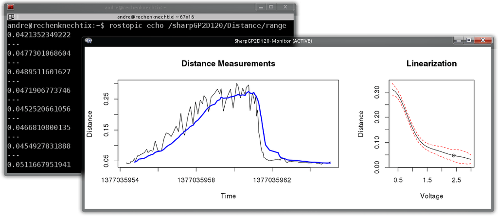

Figure 6: Screenshots of the final R application (foreground: `$ rosrun rosR_demos demo3.R`) and the published range messages in a textual format (background: `$ rostopic echo /sharp- GP2D120/Distance`) by using `rostopic` (cf. Conley 2013a).

### 4.7 Accessing the parameter server

The parameter server is also part of the ROS master and allows different nodes to exchange simple parameters (i. e., `logical`, `integer`, `double`, `character`). Accessing and storing parameters is enabled by the functions `ros.ParamSet`, `ros.ParamGet`, `ros.ParamType`, and `ros.ParamDelete`, which can be used as follows:

```r
> ros.ParamSet("name", "value")               > ros.ParamGet("name")
> ros.ParamGet("name")                        [1] 12.22
[1] "value"                                   > ros.ParamType("name")
> ros.ParamSet("name", TRUE)                  [1] "double"
> ros.ParamType("name")                       > ros.ParamDelete("name")
[1] "logical"                                 > ros.ParamType("name")
> ros.ParamSet("name", 12.22)                 NULL
```

Function `ros.ParamType` checks the type of a certain parameter, but can also be used to check if a parameter does not exist, in this case it will return `NULL`.

## 5 Implementation details

This section will give insights into the project structure and details of implementation. Thus, adapting and adding new functionality is strongly recommended. As mentioned earlier, our package was developed with the help of SWIG2.0. This is an “easy to use” tool for interfacing C and C++ libraries/programs from various languages such as Python, Tcl, Go, Guile, Java, and also R. Literally, it can be seen as a compiler that takes C and C++ declarations as input and generates wrappers as output. These interfaces and the conversion between different data formats for R are automatically generated with the help of the *Rcpp* package, which provides required R functions and a C++ library for the interconnection.

### 5.1 Structure

To ease the development and the maintenance of the code and the API, the *rosR* project was separated into an R and a C++ part:

- [`rosR/lib/`](http://svn.code.sf.net/p/ivs-ros-pkg/code/trunk/rosR/lib/): Folder for all R related files that are listed below.
  - [`ros.R`](http://svn.code.sf.net/p/ivs-ros-pkg/code/trunk/rosR/lib/ros.R): Is the main file of the project, which has to be loaded by every R node. It implements the whole *rosR* API and is therefore also responsible for loading other R files. It also contains a couple of internal helper functions, responsible for message conversion and handling. Extending the *rosR* API therefore also requires adapting this file.
  - `rosR.R` and `rosR.so`: This is the SWIG2.0 generated wrapper code for R and the compiled C++ library, which enables to access ROS via C++ objects and methods.
  - [`std_vector.R`](http://svn.code.sf.net/p/ivs-ros-pkg/code/trunk/rosR/lib/std_vector.R): This is the handmade wrapper for accessing ROS arrays. It implements a general `rros_vector` class as well as classes for every primitive data type (`std::vector<T>`). Based on these class definitions, different wrapper functions were implemented (i. e., `length`, `print`, `show`, `resize`, `pop`, `pop_back`, `back`, `front`, `clear`, and `[]`) to ease and hide the complexity of array access. This is also the right place to include additional user-defined functionality such as `sum`, `mean`, etc., which can increase the speed of execution. Vector elements can be accessed and manipulated directly with C++ functions, which is probably more advantageous than creating local vector copies.
- [`rosR/src/`](http://svn.code.sf.net/p/ivs-ros-pkg/code/trunk/rosR/src/): Includes all C++ wrappers as listed below, based on `roscpp` by (Quigley et al. 2013), `topic_tools` by (Quigley and Gerkey 2013), and `rosbag` by (Field et al. 2013).
  - [`rosR.i`](http://svn.code.sf.net/p/ivs-ros-pkg/code/trunk/rosR/src/rosR.i): The SWIG2.0 input file, used to include all below listed classes. The result is the generated wrapper file `rosR_wrap.cpp`, which allows to access all methods and classes, defined in the files below.
  - [`rosR.h`](http://svn.code.sf.net/p/ivs-ros-pkg/code/trunk/rosR/src/rosR.h)`/`[`cpp`](http://svn.code.sf.net/p/ivs-ros-pkg/code/trunk/rosR/src/rosR.cpp): Defines general functionality such as initializing a node and generating a node handle, logging, timing, and spinning. It is the right place for including basic functionality.
  - [`PublisheR.h`](http://svn.code.sf.net/p/ivs-ros-pkg/code/trunk/rosR/src/PublisheR.h)`/`[`cpp`](http://svn.code.sf.net/p/ivs-ros-pkg/code/trunk/rosR/src/PublisheR.cpp): The generation of a ROS publisher for R is more complex and was therefore outsourced. The header file contains the implementation of a specific publisher class developed for R. Other functions defined within the [`cpp`](http://svn.code.sf.net/p/ivs-ros-pkg/code/trunk/rosR/src/PublisheR.cpp)-file, only give access to this specific R-publisher and allow the modification of its settings, such as topic, message type, etc., but also to alter the content of its message buffer (derived from `topic_tools`).
  - [`SubscribeR.h`](http://svn.code.sf.net/p/ivs-ros-pkg/code/trunk/rosR/src/SubscribeR.h)`/`[`cpp`](http://svn.code.sf.net/p/ivs-ros-pkg/code/trunk/rosR/src/SubscribeR.cpp): The subscriber was developed similarly to the implementation of the publisher. The header filer contains the implementation of a specific R subscriber. Due to the fact that callbacks cannot be defined within R, every `SubscribeR` object also contains a callback method, which comes into play when `ros::SpinOnce()` is activated. It receives and stores every new message. Other functions defined within these files give access to the subscriber and its message buffer.
  - [`BagR.h`](http://svn.code.sf.net/p/ivs-ros-pkg/code/trunk/rosR/src/BagR.h)`/`[`cpp`](http://svn.code.sf.net/p/ivs-ros-pkg/code/trunk/rosR/src/BagR.cpp) and [`ParamR.h`](http://svn.code.sf.net/p/ivs-ros-pkg/code/trunk/rosR/src/ParamR.h)`/`[`cpp`](http://svn.code.sf.net/p/ivs-ros-pkg/code/trunk/rosR/src/ParamR.cpp): As the names suggest, these files contain the functions to read out bag-files and give access to the parameter server.
  - `rosR_wrap.cxx`: This file contains the generated wrapper and conversion functionality for C++, which is based on *Rcpp*.

### 5.2 SWIG by example

The following two functions are taken from [`ParamR.cpp`](http://svn.code.sf.net/p/ivs-ros-pkg/code/trunk/rosR/src/ParamR.cpp). The first function is used to retrieve string parameters from the parameter server, similar functions were also defined to retrieve `double`, `boolean`, and `integer` values. The second function identifies the type of the parameter, returning the type as a string and the string `NULL`, if the parameter does not exist.

```r
char* rrosGetParamString(                  char* rrosGetParamType(ros::NodeHandle* h,
   ros::NodeHandle* handle,                    char* p)//(==param) requested parameter
   char* param)                            {
{                                            bool b; int i; double d; std::string s;
  std::string val;                           if(h->getParam(p, b)) return "logical";
  handle->getParam(param, val);              if(h->getParam(p, i)) return "integer";
  return const_cast<char*>(val.c_str());     ...
}                                            return "NULL"; }
```

After SWIG2.0 did its magic, these C++ functions are also callable from R (with their pervious C++ function names). The API functions `ros.ParamGet` and `ros.ParamType` are simple workarounds (defined in [`rosR/lib/ros.R`](http://svn.code.sf.net/p/ivs-ros-pkg/code/trunk/rosR/lib/ros.R)) that hide the different data types and therefore different C++ function calls:

```r
ros.ParamGet <- function(param) {          # "rros_node" is a pointer to the ROS node-
  p <- param; h <-rros_node;               # handle, which was created during the ini-
  type <- ros.ParamType(param)             # tialization by "ros.Init()".
  if (type == "logical") {                 # It is stored as a global variable and re-
    return(rrosGetParamBoolean(h, p))      # quired by most of the rosR API functions.
  } else if (type == "integer") {
    return(rrosGetParamInteger(h, p))      ros.ParamType <- function(param) {
  } else if (type == "double") {             p <- param; h <-rros_node;
    return(rrosGetParamDouble(h, p))         type <- rrosGetParamType(h, p)
  } else if (type == "character") {          if (type == "NULL") {
    return(rrosGetParamString(h, p))           return(NULL) }
  } else { return(NULL) } }                  return(type) }
```

The other functions of our API were also implemented in the same manner (cf. [`ros.R`](http://svn.code.sf.net/p/ivs-ros-pkg/code/trunk/rosR/lib/ros.R)), while announcing a subscriber or a publisher (and also the initialization with `ros.Init`) also generate specified objects. The wrapper functions for writing and reading out messages therefore always require the pointer to these objects, to get access to their public class methods.

## 6 Summary

We have developed the first interface for ROS in R and demonstrated its utility as well as its main concepts, which represents a fruitful combination of the (interdisciplinary) world of robotics with the world of statistics. On the one hand, it gives ROS developers full access to the huge amount of R algorithms and functionality for analyzing, visualizing, combining and filtering data. And on the other hand, it will probably open up a new branch to the R community, by giving online access to real hardware devices and their data, in contrast to the traditional offline data analysis.

But, there is still a lot of work to do. The next extensions should cover the integration of [services](http://www.ros.org/wiki/Services), which could be used for parameter fitting, clustering, machine learning, or pattern matching. Furthermore, it would be beneficial to develop methods in R that would enable callback mechanisms or multi-threading, to overcome polling for new messages.

## 7 Acknowledgements

This work is funded and supported by the German Ministry of Education and research within the project [ViERforES-II](http://www.vivera.org/ViERforES) (grant no. 01IM10002B) and by the EU FP7-ICT program under the contract number 288195 “Kernel-based ARchitecture for safetY-critical cONtrol” ([KARYON](http://www.karyon-project.eu)).

### 7.1 CRAN packages used

Rcpp

### 7.2 CRAN Task Views implied by cited packages

HighPerformanceComputing, NumericalMathematics

A. Blasdel. Rqt_console: A GUI plugin for displaying and filtering ROS messages. 2013. URL http://wiki.ros.org/rqt_console. [Online; accessed 16-December-2013].

K. Conley. Rostopic: Command-line tool for displaying debug information. 2013a. URL http://wiki.ros.org/rostopic. [Online; accessed 16-December-2013].

K. Conley. Rxgraph: Command-line tool for visualizing a ROS computation graph. 2013b. URL http://www.ros.org/wiki/rxgraph. [Online; accessed 16-December-2013].

K. Conley and T. Foote. Rosmsg: Command-line tool for displaying information about ROS message types. 2013. URL http://wiki.ros.org/rosmsg. [Online; accessed 16-December-2013].

Sharp Cooperation. *Sharp GP2D120 – optoelectronic device.* 2007. URL http://www.sharpsma.com/webfm\_send/1205.

A. Dietrich, S. Zug and J. Kaiser. Detecting external measurement disturbances based on statistical analysis for smart sensors. In *Proceedings of the IEEE international symposium on industrial electronics (ISIE)*, pages. 2067–2072 2010. Bari, Italy.

D. Eddelbuettel and R. François. Rcpp: Seamless R and C++ integration. *Journal of Statistical Software*, 40(8): 1–18, 2011. URL http://www.jstatsoft.org/v40/i08/.

T. Field, J. Leibs and J. Bowman. Rosbag: A set of tools for recording from and playing back to ROS topics. 2013. URL http://wiki.ros.org/rosbag. [Online; accessed 16-December-2013].

T. Foote. Rosmake: A ROS dependency aware build tool. 2013. URL http://wiki.ros.org/rosmake. [Online; accessed 16-December-2013].

B. Gerkey, M. Quigley and D. Thomas. Rospack: ROS package management tool. 2013. URL http://docs.ros.org/independent/api/rospkg/html/rospack.html. [Online; accessed 16-December-2013].

J. Kramer and M. Scheutz. Development environments for autonomous mobile robots: A survey. *Autonomous Robots*, 22: 101–132, 2007.

J. Leibs and T. Kruse. Rosrun: Allows you to run an executable in an arbitrary package from anywhere without having to give its full path. 2013. URL http://wiki.ros.org/rosbash\#rosrun. [Online; accessed 16-December-2013].

M. Quigley, K. Conley, B. Gerkey, J. Faust, T. Foote, J. Leibs, R. Wheeler and A. Y. Ng. ROS: An open-source robot operating system. In *ICRA workshop on open source software*, 2009.

M. Quigley, J. Faust, B. Gerkey and T. Straszheim. Roscpp: C++ implementation of ROS. 2013. URL http://wiki.ros.org/roscpp. [Online; accessed 16-December-2013].

M. Quigley and B. Gerkey. Topic_tools: Directing, throttling, selecting, and otherwise messing with ROS topics at a meta level. 2013. URL http://wiki.ros.org/topic_tools. [Online; accessed 16-December-2013].

P. H. Salus. *A quarter century of unix.* Addison-Wesley Longman, 1994.

SWIG-2.0. Documentation. 2013. URL http://www.swig.org/Doc2.0/SWIGDocumentation.html. [Online; accessed 21-July-2013].

Wikipedia. Comparison of statistical packages – Wikipedia, The Free Encyclopedia. 2013. URL http://en.wikipedia.org/wiki/Comparison\_of\_statistical\_packages. [Online; accessed 21-July-2013].

[^1]: Official ROS project website: http://www.ROS.org
[^2]: ROS language extensions for C++, Python, Lisp, Java, and Lua.
[^3]: For a complete list of supported programming languages see [http://www.ros.org/wiki/Client Libraries](http://www.ros.org/wiki/Client%20Libraries).